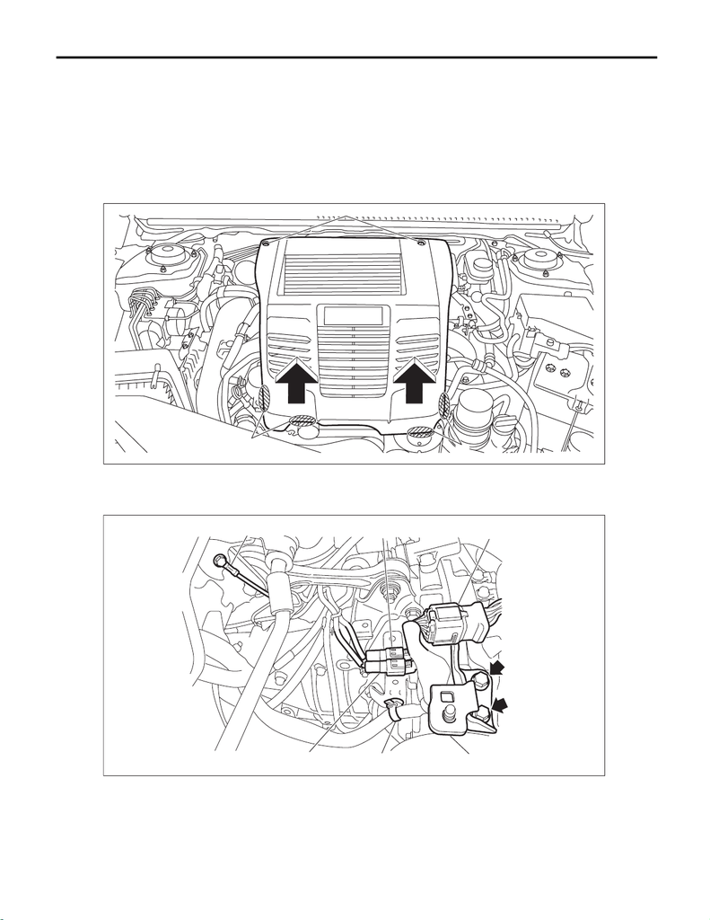

6MT(TY75)-25

Manual Transmission Assembly

MANUAL TRANSMISSION AND DIFFERENTIAL

3. Manual Transmission Assembly

A: REMOVAL

1) Open the front hood completely.

2) Disconnect the ground cable from battery. <Ref. to NT-5, BATTERY, NOTE, Note.>

3) Remove the collector cover.

(1) Remove the clips (A).

(2) Hold the shaded area (B) by hand and carefully pull the RH side (C) upward.

(3) Hold the shaded area (D) by hand and carefully pull the LH side (E) upward.

4) Remove the intercooler and the intercooler stay. <Ref. to IN(w/o STI)-38, REMOVAL, Intercooler.>

5) Disconnect the clips and the following connectors, then remove the transmission radio ground cord termi-

nal and the engine rear hanger.

(A) Neutral position switch connector

(brown)

(B) Back-up light switch connector

(gray)

(C) Engine harness connector

(brown)

(D) Clip (E) Transmission radio ground cord

terminal

(F) Engine rear hanger

EX-03204

(A)

(B)

(C)

(E)

(D)

MT-03106

(B)

(D)

(C)

(A)

(E)

(F)

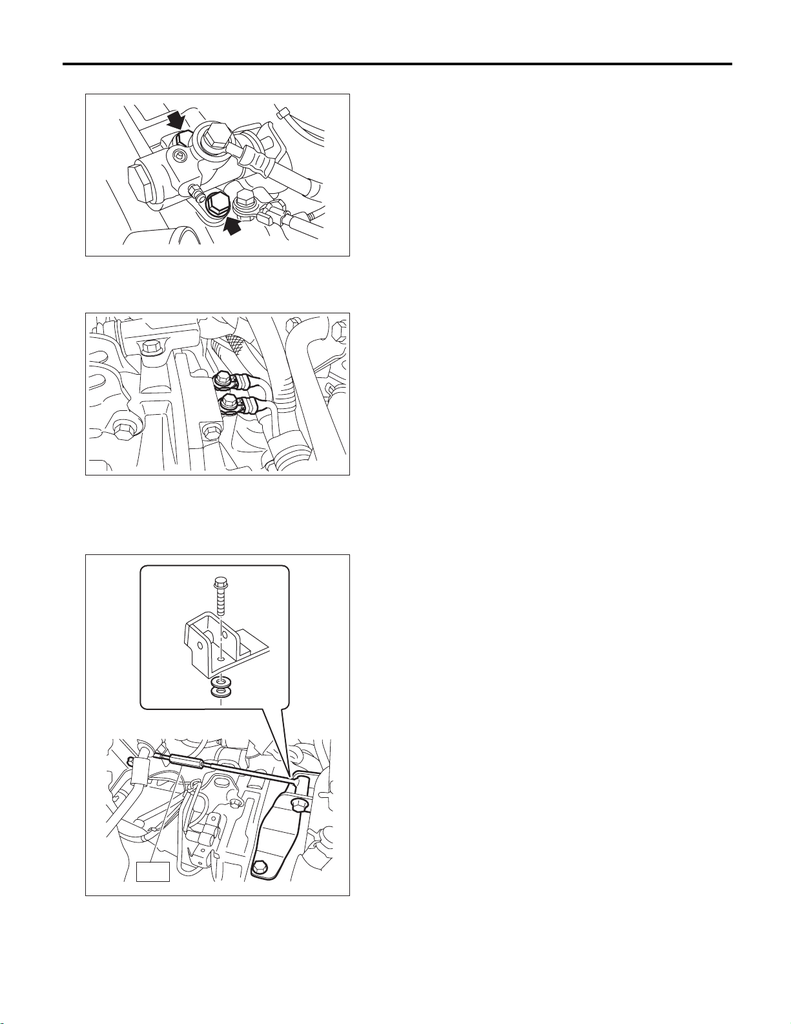

6MT(TY75)-26

Manual Transmission Assembly

MANUAL TRANSMISSION AND DIFFERENTIAL

6) Remove the operating cylinder and suspend on a wire.

7) Remove the pitching stopper. <Ref. to 6MT(TY75)-36, PITCHING STOPPER, REMOVAL, Transmission

Mounting System.>

8) Disconnect the engine ground terminal.

9) Set the ST.

NOTE:

Place a washer with 4 mm (0.16 in) thickness into the gap between the engine block and ST.

ST 41099AC000 ENGINE SUPPORT ASSY

10) Remove the starter. <Ref. to SC(w/o STI)-7, REMOVAL, Starter.>

MT-03201

MT-03069

MT-03116

ST

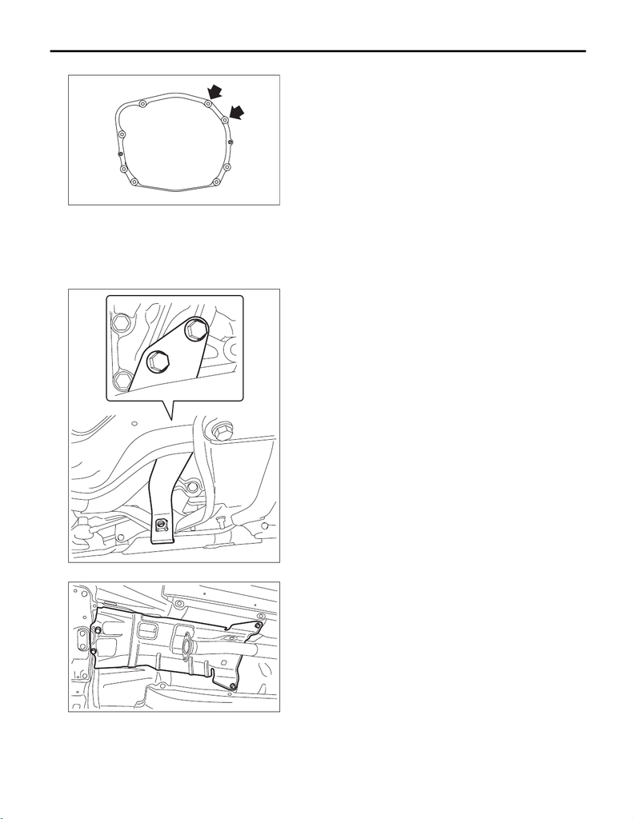

6MT(TY75)-27

Manual Transmission Assembly

MANUAL TRANSMISSION AND DIFFERENTIAL

11) Remove the bolts which hold upper side of transmission to engine.

12) Remove the front wheels.

13) Lift up the vehicle.

14) Remove the center exhaust pipe (rear). <Ref. to EX(w/o STI)-35, REMOVAL, Center Exhaust Pipe.>

15) Drain transmission gear oil completely. <Ref. to 6MT(TY75)-24, REPLACEMENT, Transmission Gear

Oil.>

16) Remove the hanger bracket.

17) Remove the center exhaust cover.

18) Remove the propeller shaft. <Ref. to DS-12, REMOVAL, Propeller Shaft.>

MT-01524

MT-03074

MT-03072

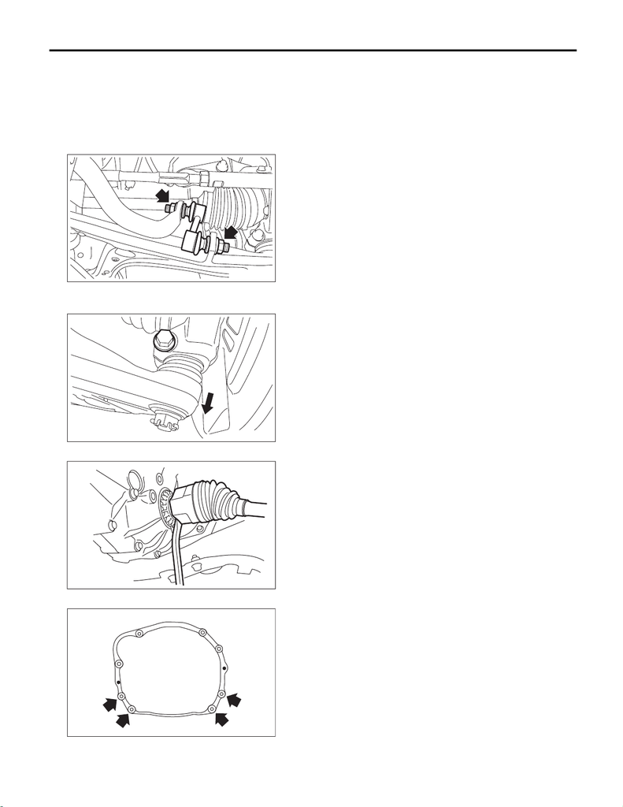

6MT(TY75)-28

Manual Transmission Assembly

MANUAL TRANSMISSION AND DIFFERENTIAL

19) Remove the MT gear shift cable and MT gear select cable from MT gear shift lever. <Ref. to CS-58, EX-

CEPT FOR STI MODEL, REMOVAL, MT Gear Shift Lever.>

CAUTION:

• Do not bend MT gear shift cable and MT gear select cable at a sharp angle.

• If the MT gear select cable is removed from the selector lever COMPL on the transmission side, re-

place with new MT gear select cable.

20) Remove the stabilizer link.

21) Remove the bolt securing the ball joint of the front arm to the housing, then separate the front arms and

the housing.

22) Using a crowbar, separate the left and right front drive shafts.

23) Remove the bolts and nuts which hold lower side of transmission to engine.

MT-03070

MT-03073

MT-02593

MT-00077

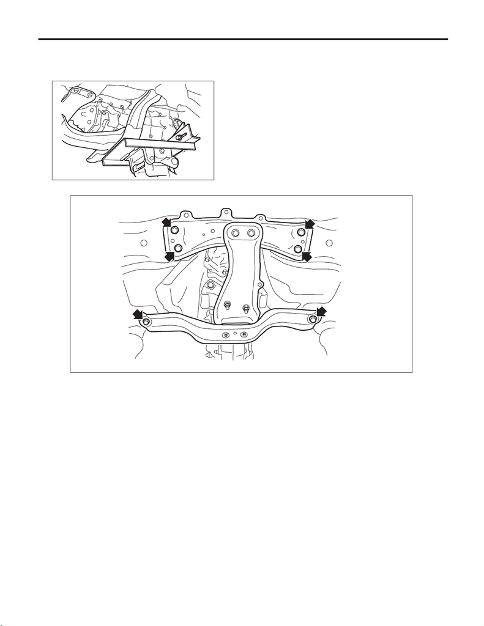

6MT(TY75)-29

Manual Transmission Assembly

MANUAL TRANSMISSION AND DIFFERENTIAL

24) Place the transmission jack under the transmission.

CAUTION:

Always support the transmission case with a transmission jack.

25) Remove the front crossmember and the rear crossmember.

26) While lowering the transmission jack, tighten the turnbuckle of the ST, and incline the engine unit rear-

ward.

27) Remove the transmission.

NOTE:

Move the transmission jack towards the rear until the main shaft is withdrawn from the clutch disc.

28) Remove the transmission cushion rubber from the transmission assembly.

MT-02758

MT-03182

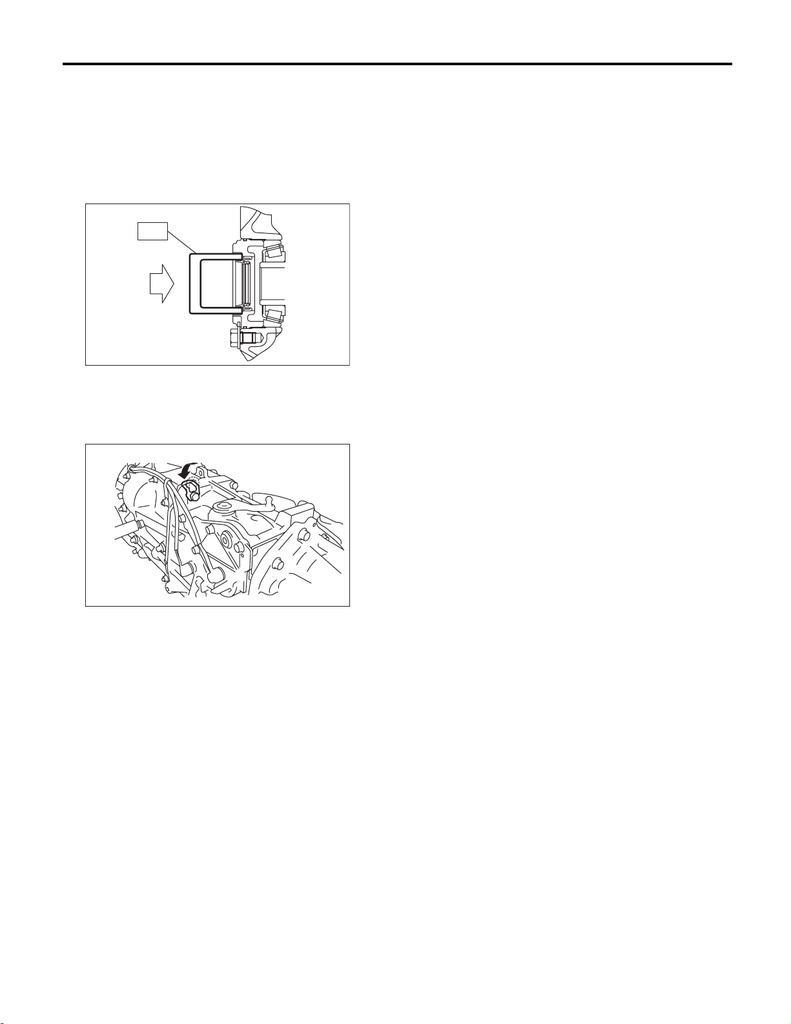

6MT(TY75)-30

Manual Transmission Assembly

MANUAL TRANSMISSION AND DIFFERENTIAL

B: INSTALLATION

1) Replace the differential side retainer oil seal. <Ref. to 6MT(TY75)-42, REPLACEMENT, Differential Side

Retainer Oil Seal.>

NOTE:

• Be sure to replace the differential side retainer oil seal after removing the front drive shaft.

• When a new oil seal has been installed, replacement is not required.

ST 18675AA000 DIFFERENTIAL SIDE OIL SEAL INSTALLER

2) Tap the transmission hanger in the rear side of transmission with a rubber hammer to bend it until full con-

tact is obtained.

CAUTION:

Do not apply excessive load or impact to the transmission case.

3) Install the transmission cushion rubber to the transmission, and tighten the bolt (A).

ST

MT-00103

MT-02685

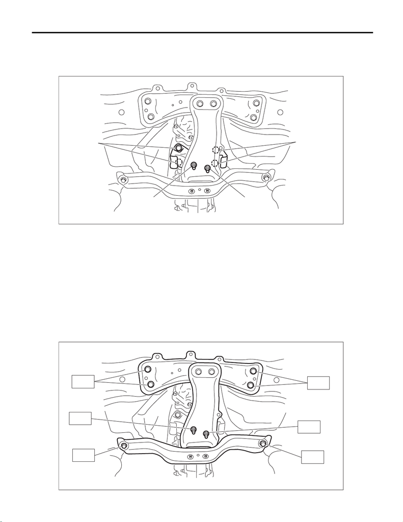

6MT(TY75)-31

Manual Transmission Assembly

MANUAL TRANSMISSION AND DIFFERENTIAL

Tightening torque:

Bolt (A)

35 N·m (3.6 kgf-m, 25.8 ft-lb)

5) Install the transmission onto the engine.

(1) Lift up the transmission gradually using a transmission jack.

(2) Engage at the spline section.

NOTE:

Be careful not to hit the main shaft against the clutch cover.

6) While raising the transmission jack, loosen the turnbuckle of the ST, and set the engine unit to the original

position.

7) Tighten the mounting bolts for front crossmember and rear crossmember.

8) Tighten the transmission cushion rubber mounting nut.

Tightening torque:

T1: 70 N·m (7.1 kgf-m, 51.6 ft-lb)

T2: 140 N·m (14.3 kgf-m, 103.3 ft-lb)

T3: 35 N·m (3.6 kgf-m, 25.8 ft-lb)

MT-03185

(A)(A)

(A)

(B)

(B)

MT-03183

T1

T1

T3

T3

T2

T2

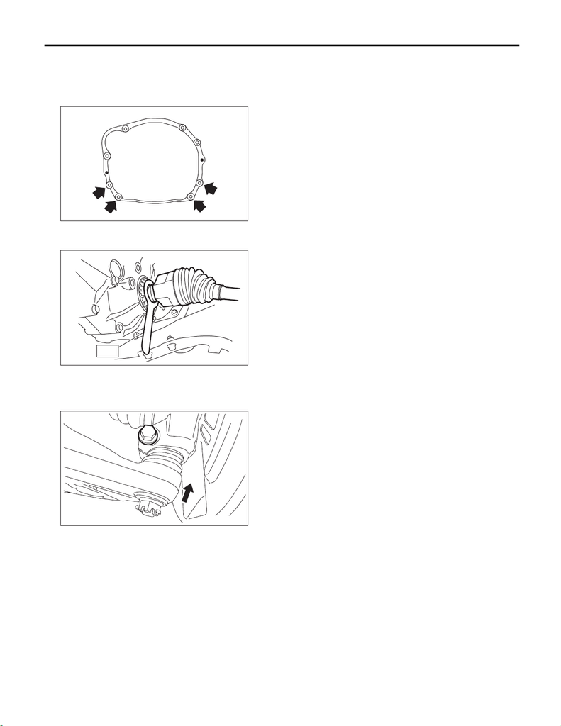

6MT(TY75)-32

Manual Transmission Assembly

MANUAL TRANSMISSION AND DIFFERENTIAL

9) Take out the transmission jack.

10) Tighten the bolts and nuts which hold the lower side of transmission to the engine.

Tightening torque:

50 N·m (5.1 kgf-m, 36.9 ft-lb)

11) Install the ST to the transmission, and then install the front drive shaft.

ST 28399SA010 OIL SEAL PROTECTOR

12) Insert the front arm ball joint and tighten the mounting bolt.

Tightening torque:

50 N·m (5.1 kgf-m, 36.9 ft-lb)

MT-00077

MT-02693

ST

MT-03093

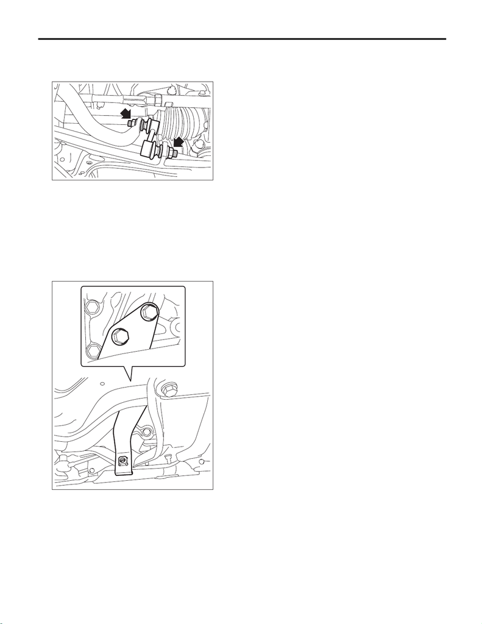

6MT(TY75)-33

Manual Transmission Assembly

MANUAL TRANSMISSION AND DIFFERENTIAL

13) Install the stabilizer link.

Tightening torque:

60 N·m (6.1 kgf-m, 44.3 ft-lb)

14) Install the MT gear shift cable and MT gear select cable to MT gear shift lever. <Ref. to CS-64, EXCEPT

FOR STI MODEL, INSTALLATION, MT Gear Shift Lever.>

CAUTION:

• Do not bend MT gear shift cable and MT gear select cable at a sharp angle.

• If the MT gear select cable is removed from the selector lever COMPL on the transmission side, re-

place with new MT gear select cable.

15) Install the hanger bracket.

Tightening torque:

23 N·m (2.3 kgf-m, 17.0 ft-lb)

16) Install the propeller shaft. <Ref. to DS-14, INSTALLATION, Propeller Shaft.>

17) Install the center exhaust cover.

Tightening torque:

18 N·m (1.8 kgf-m, 13.3 ft-lb)

MT-03070

MT-03074

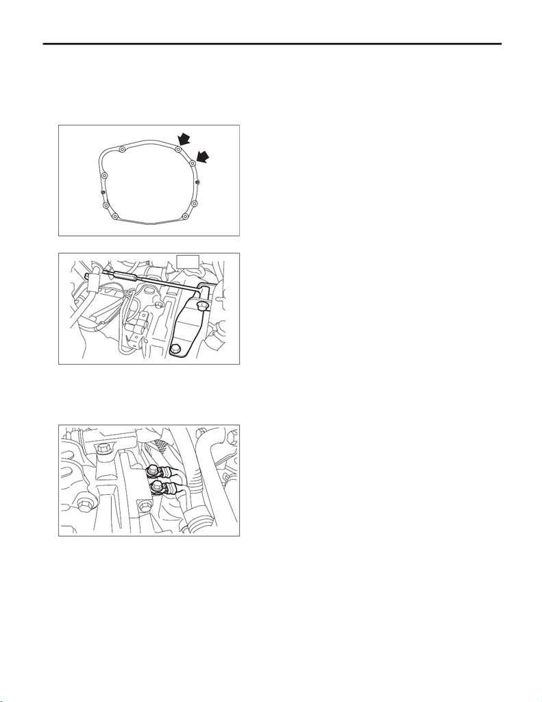

6MT(TY75)-34

Manual Transmission Assembly

MANUAL TRANSMISSION AND DIFFERENTIAL

18) Install the center exhaust pipe (rear). <Ref. to EX(w/o STI)-41, INSTALLATION, Center Exhaust Pipe.>

19) Lower the vehicle.

20) Install the starter. <Ref. to SC(w/o STI)-9, INSTALLATION, Starter.>

21) Tighten the bolts which hold the upper side of the transmission to the engine.

Tightening torque:

50 N·m (5.1 kgf-m, 36.9 ft-lb)

22) Remove the ST.

23) Install the pitching stopper. <Ref. to 6MT(TY75)-38, PITCHING STOPPER, INSTALLATION, Transmis-

sion Mounting System.>

24) Install the engine ground terminals.

Tightening torque:

19 N·m (1.9 kgf-m, 14.0 ft-lb)

MT-01524

MT-03095

ST

MT-03069

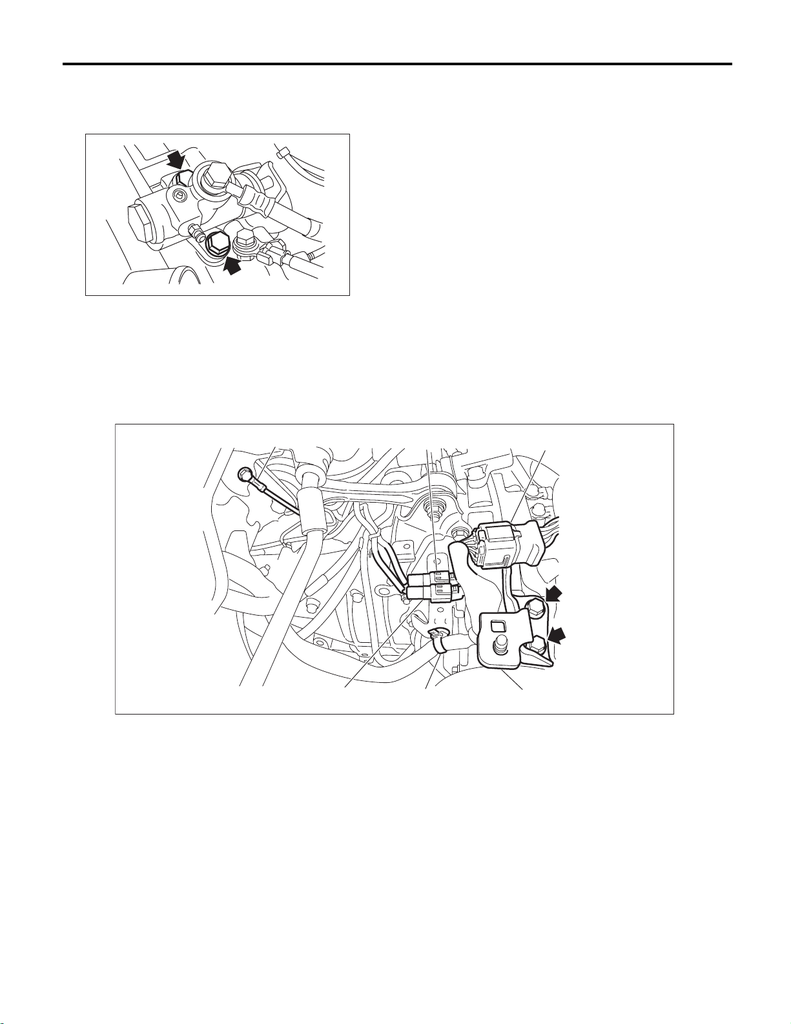

6MT(TY75)-35

Manual Transmission Assembly

MANUAL TRANSMISSION AND DIFFERENTIAL

25) Install the operating cylinder.

Tightening torque:

37 N·m (3.8 kgf-m, 27.3 ft-lb)

26) Install the transmission radio ground cord terminal and the engine rear hanger, connect the following

connectors, and then secure the clip on the bracket.

Tightening torque:

Transmission radio ground cord terminal

13 N·m (1.3 kgf-m, 9.6 ft-lb)

Engine rear hanger

21 N·m (2.1 kgf-m, 15.5 ft-lb)

27) Pour in transmission gear oil and check the oil level. <Ref. to 6MT(TY75)-23, Transmission Gear Oil.>

28) Install the intercooler stay and the intercooler. <Ref. to IN(w/o STI)-41, INSTALLATION, Intercooler.>

29) Install the collector cover.

30) Install the front tires.

31) Adjust the detent of the MT gear shift lever. <Ref. to CS-82, ADJUSTMENT, MT Gear Shift Lever.>

32) Connect the battery ground terminal. <Ref. to NT-5, BATTERY, NOTE, Note.>

MT-03201

(A) Neutral position switch connector

(brown)

(B) Back-up light switch connector

(gray)

(C) Engine harness connector

(brown)

(D) Clip (E) Transmission radio ground cord

terminal

(F) Engine rear hanger

MT-03106

(B)

(D)

(C)

(A)

(E)

(F)